# SVM & Clustering

INFO 521 · Module 6 · Lecture B — k-means & the Unsupervised Turn

Greg Chism

College of Information Science · University of Arizona

August 2026

## Learning outcomes

By the end of Lecture B you should be able to:

1. **Pose the clustering problem** — structure in $\mathbf{X}$, no $\mathbf{y}$.
2. **Run k-means** — assign / update — and state its distortion objective $\mathcal{L}$.
3. **Diagnose its failure modes** — local optima, choosing $k$, scaling.
4. **Refuse the free lunch** — clusters are *not* labels; say why with data.

## The unsupervised turn

Every method so far consumed pairs $(\mathbf{x}_n, y_n)$. Delete the labels:

$$\mathcal{D} = \{\mathbf{x}_1, \dots, \mathbf{x}_N\} \subset \mathbb{R}^{D}
\qquad\text{— no } y_n \text{, no "right answer".}$$

- **Clustering** — do the patients form *groups*? (today)
- **Dimensionality reduction** — do the features hide a *simpler description*? (Module 7)

Without $\mathbf{y}$ there is no test-set truth to check against — evaluation becomes *internal* (fit to structure) plus *judgment* (is it meaningful?).

## k-means: the objective

Choose $K$ **centroids** $\boldsymbol{\mu}_k$ and an assignment $z_n \in \{1..K\}$ for each patient, minimizing the **distortion** — a loss again, so $\mathcal{L}$:

$$\mathcal{L}\bigl(\{z_n\}, \{\boldsymbol{\mu}_k\}\bigr)
= \sum_{n=1}^{N} \bigl\lVert \mathbf{x}_n - \boldsymbol{\mu}_{z_n} \bigr\rVert_2^2$$

Two interlocking sub-problems, each trivial with the other fixed:

- **Assign** (fix $\boldsymbol{\mu}$): send each $\mathbf{x}_n$ to its nearest centroid.
- **Update** (fix $z$): move each centroid to the **mean** of its members — the squared-error-minimizing point (m1a’s loss, yet again).

Alternate until nothing moves. Each step lowers $\mathcal{L}$ ⇒ **guaranteed to converge** — though not necessarily to the best answer.

## k-means on NHANES: the adiposity plane

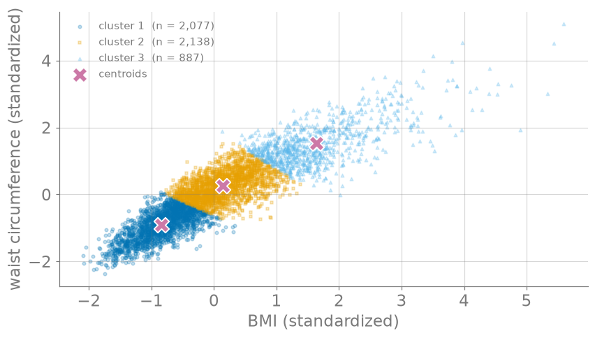

Figure 1: k-means (K = 3, from scratch, seed 521) on standardized (BMI, waist): the algorithm slices the adiposity continuum into bands; purple ✕ = centroids.

## Standardize first — distances have units

k-means lives on **Euclidean distance**, so the feature scales *are* the model:

- Raw units: waist (cm, SD ≈ 17) would out-shout HbA1c (%, SD ≈ 1) hundreds-fold — clustering would be “waist, with commentary.”
- Standardizing (each feature to mean 0, SD 1) gives features an equal vote — the same move as m1a’s standardized age, now **load-bearing**.
- No distance-based method is scale-free: choosing units **is** choosing the answer.

## Local optima: restarts are not optional

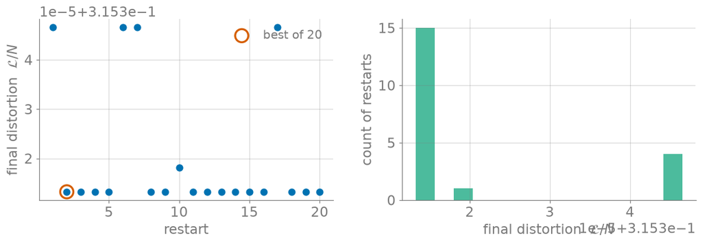

Figure 2: 20 random initializations, K = 4, same data: k-means lands on different local optima — keep the restart with the lowest 𝓛.

## Choosing K: the elbow, honestly

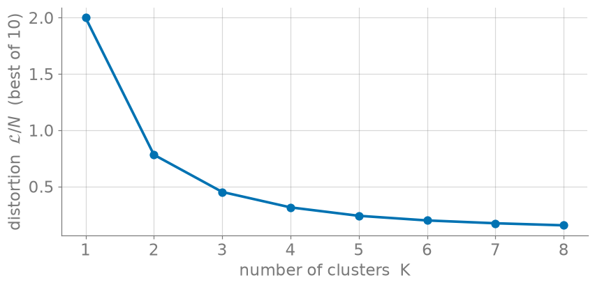

Figure 3: Distortion vs. K (best of 10 restarts each): always decreasing — the question is where it stops being worth it. Here: a soft elbow, not a verdict.

- $\mathcal{L}$ **always** falls with $K$ (at $K{=}N$ it is zero) — m2a’s training-error trap, wearing clusters.
- Look for the **elbow** where marginal gain collapses… and accept that real data often gives a *soft* one. $K$ is a modeling **choice**, owned and argued.

## Hard assignments → soft: the GMM bridge

k-means gives every patient exactly one cluster — even on the fence. The probabilistic upgrade: a **Gaussian mixture model**,

$$p(\mathbf{x}) = \sum_{k=1}^{K} \pi_k\, \mathcal{N}(\mathbf{x} \mid \boldsymbol{\mu}_k, \boldsymbol{\Sigma}_k),$$

fit by **EM** — the same assign/update dance, made soft:

- **E-step**: *responsibilities* $r_{nk} = p(z_n{=}k \mid \mathbf{x}_n)$ replace hard $z_n$ (Bayes’ rule, m4a, inside the loop).
- **M-step**: weighted MLE updates (m3a) for $\pi_k, \boldsymbol{\mu}_k, \boldsymbol{\Sigma}_k$.
- k-means **is** the $\boldsymbol{\Sigma}_k \to \varepsilon\mathbf{I}$ limit — hard assignment is a shrunk-covariance special case.

## Clusters are not diagnoses

Color the K = 3 adiposity clusters by the **held-back** hypertension label:

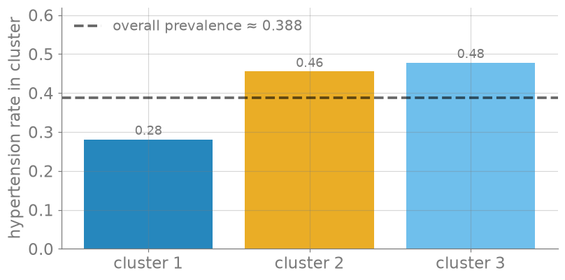

Figure 4: Hypertension rate inside each K = 3 cluster vs. overall prevalence (dashed): adiposity clusters ENRICH risk — none of them IS the diagnosis.

- The clusters **never saw** blood pressure (leakage rule, m1a) — yet risk climbs across them: unsupervised structure is *related* to the outcome…
- …but no cluster is remotely pure. **Pretending clusters are labels manufactures diagnoses the data never made.** Part 2’s honesty requirement, in one figure.

## Live demo: the k-means explorer

Step assign / update by hand in the week05 tool — trap it in a local optimum, then rescue it with a restart.

## Explorer — static fallback

*The iframe above does not print or export to PDF; this snapshot stands in.*

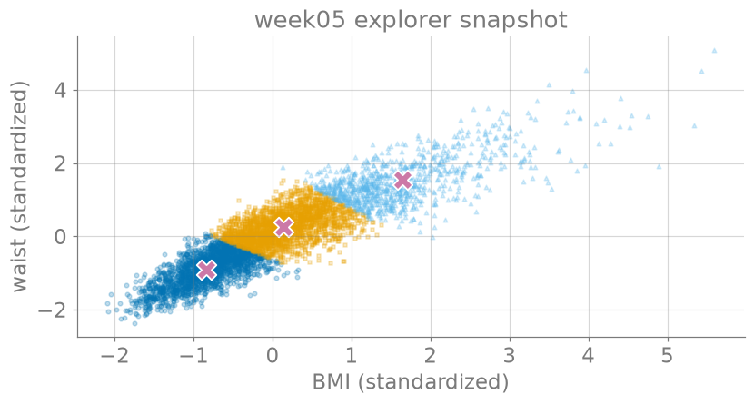

Figure 5: Static fallback: k-means on the NHANES adiposity plane (used in print / PDF).

## Recap & bridge

**Next (Module 7):** the other unsupervised question — not “which groups?” but “which *directions* matter?” PCA, and the course’s closing synthesis.